# Data Cleansing02

Mino

Saturday, February 14, 2015

## 날짜 다루기

```r
time = Sys.time() # 현재시각

weekdays(time)
```

```
## [1] "토요일"
```

```r
months(time)
```

```
## [1] "2월"
```

```r
quarters(time)
```

```
## [1] "Q1"
```

```r
strftime(time,"%Y-%m-%d %H:%M:%S")
```

```
## [1] "2015-02-14 13:17:01"
```

```r
strftime(time, "%m/%d")
```

```
## [1] "02/14"
```

```r
strftime(time, "%Y-%m-%d")
```

```
## [1] "2015-02-14"
```

```r
strftime(time, "%Y")
```

```
## [1] "2015"
```

```r
strftime(time, "%w") # 요일 : 일요일이 0일 때 0~6으로 표현
```

```
## [1] "6"
```

- `?strftime`으로 자세한 포맷 옵션을 확인
- `as.Date()` : 문자열 -> 날짜

```r
str_time = "20150214"
date_time = as.Date(str_time, format = "%Y%m%d")
date_time + 1
```

```
## [1] "2015-02-15"
```

```r
date_time + 1:7
```

```
## [1] "2015-02-15" "2015-02-16" "2015-02-17" "2015-02-18" "2015-02-19"
## [6] "2015-02-20" "2015-02-21"
```

```r
weekdays(date_time)
```

```
## [1] "토요일"
```

- `gcookbook` 패키지의 `aapl` 데이터를 가지고 활용해보자

```r
# install.packages("gcookbook")
library(gcookbook)
library(dplyr)
head(aapl) # Weekly stock data for Apple, Inc. from 1984 to 2012
```

```
##         date adj_price
## 1 1984-09-07      3.01
## 2 1984-09-14      3.17
## 3 1984-09-21      3.05
## 4 1984-09-28      2.85
## 5 1984-10-05      2.83
## 6 1984-10-12      2.58
```

```r
str(aapl) # Date 형식
```

```
## 'data.frame':    1466 obs. of  2 variables:
##  $ date     : Date, format: "1984-09-07" "1984-09-14" ...
##  $ adj_price: num  3.01 3.17 3.05 2.85 2.83 2.58 2.91 2.8 2.83 2.64 ...
```

### 요일, 월, 분기 구분하기

```r
aapl_date <- aapl %>%
  mutate(weekday = weekdays(date),
         month = months(date),
         quarter = quarters(date))

head(aapl_date)
```

```
##         date adj_price weekday month quarter
## 1 1984-09-07      3.01  금요일   9월      Q3
## 2 1984-09-14      3.17  금요일   9월      Q3
## 3 1984-09-21      3.05  금요일   9월      Q3
## 4 1984-09-28      2.85  금요일   9월      Q3
## 5 1984-10-05      2.83  금요일  10월      Q4
## 6 1984-10-12      2.58  금요일  10월      Q4
```

### 연도 구분하기

```r
aapl_date <- aapl_date %>%
  mutate(year = strftime(date, "%Y"))

head(aapl_date)
```

```
##         date adj_price weekday month quarter year
## 1 1984-09-07      3.01  금요일   9월      Q3 1984
## 2 1984-09-14      3.17  금요일   9월      Q3 1984
## 3 1984-09-21      3.05  금요일   9월      Q3 1984
## 4 1984-09-28      2.85  금요일   9월      Q3 1984
## 5 1984-10-05      2.83  금요일  10월      Q4 1984
## 6 1984-10-12      2.58  금요일  10월      Q4 1984
```

### 연도별 평균

```r
aapl_year <- aapl_date %>%
  group_by(year) %>%
  summarise(mean_price = mean(adj_price))

head(aapl_year)
```

```
## Source: local data frame [6 x 2]
##
##   year mean_price
## 1 1984   2.897647
## 2 1985   2.294423
## 3 1986   3.683462
## 4 1987   8.875094
## 5 1988   9.492500
## 6 1989   9.637692
```

### 연도별 평균 가격에 대한 막대그래프

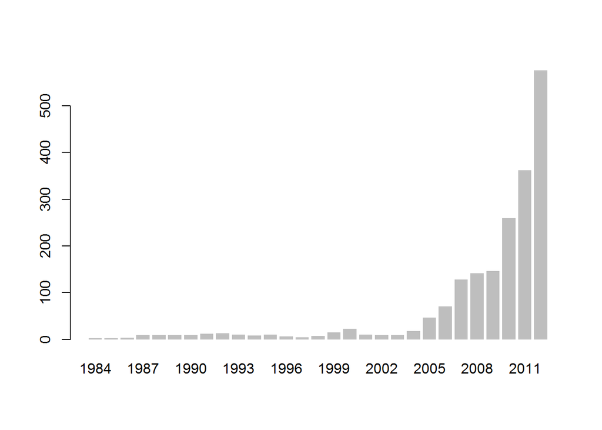

```r
barplot(aapl_year$mean_price,
        names.arg = aapl_year$year,
        border = NA)
```

### 분기별 평균

```r
aapl_qt <- aapl_date %>%
  group_by(quarter) %>%
  summarise(mean_price = mean(adj_price))

head(aapl_qt)
```

```
## Source: local data frame [4 x 2]
##
##   quarter mean_price
## 1      Q1   59.01022
## 2      Q2   67.27605
## 3      Q3   72.66731
## 4      Q4   56.26689
```

## NA(결측치) 다루기

**NA : Not Available**, 일반적으로 결측치를 나타낸다

`?NA`에서 자세한 내용을 볼 수 있다

**NA의 특성** : 연산을 해도 결과가 NA

```r
NA+1
```

```
## [1] NA
```

```r
NA & TRUE
```

```
## [1] NA
```

- 평균, 분산 등의 연산에서 NA 값이 포함되면 결과물도 NA로 나온다

```r
mean_na = c(1, 2, 3, NA, 5)
mean_na
```

```
## [1]  1  2  3 NA  5
```

```r
mean(mean_na) # NA가 나온다
```

```
## [1] NA
```

```r
sum(mean_na)
```

```
## [1] NA
```

```r
var(mean_na)
```

```
## [1] NA
```

- na.rm 옵션이 있는 경우 TRUE로 바꿔주면 NA를 제외하고 계산한다

```r
mean(mean_na, na.rm = TRUE)
```

```
## [1] 2.75
```

```r
sum(mean_na, na.rm = TRUE)
```

```
## [1] 11
```

```r
var(mean_na, na.rm = TRUE)
```

```
## [1] 2.916667
```

- `is.na()`함수를 통해 NA여부를 판단할 수 있다

```r
is.na(mean_na)
```

```
## [1] FALSE FALSE FALSE  TRUE FALSE
```

```r
mean_narm <- mean_na
mean_narm[is.na(mean_narm)] = 0
mean_narm
```

```
## [1] 1 2 3 0 5
```

- iris 데이터를 활용해서 NA가 포함된 샘플을 만들어보자

```r
iris_na <- iris[1:5, ]
iris_na[2,2] = NA
iris_na[1,3] = NA
iris_na
```

```
##   Sepal.Length Sepal.Width Petal.Length Petal.Width Species
## 1          5.1         3.5           NA         0.2  setosa
## 2          4.9          NA          1.4         0.2  setosa
## 3          4.7         3.2          1.3         0.2  setosa
## 4          4.6         3.1          1.5         0.2  setosa
## 5          5.0         3.6          1.4         0.2  setosa
```

- `na.omit()` : NA가 포함된 행을 제외

```r
na.omit(iris_na)
```

```
##   Sepal.Length Sepal.Width Petal.Length Petal.Width Species
## 3          4.7         3.2          1.3         0.2  setosa
## 4          4.6         3.1          1.5         0.2  setosa
## 5          5.0         3.6          1.4         0.2  setosa
```

- `complete.cases()` : NA가 없는 행은 TRUE, NA가 존재하면 FALSE로 행을 출력

```r
complete.cases(iris_na)
```

```
## [1] FALSE FALSE  TRUE  TRUE  TRUE
```

```r
iris_na %>%
  filter(complete.cases(iris_na) == FALSE)
```

```
##   Sepal.Length Sepal.Width Petal.Length Petal.Width Species
## 1          5.1         3.5           NA         0.2  setosa
## 2          4.9          NA          1.4         0.2  setosa
```

- `mutate`와 `ifelse`를 이용한 NA처리

```r
iris_na %>%
  mutate(Sepal.Width_rm = ifelse(is.na(Sepal.Width)==TRUE, 0, Sepal.Width),
         Petal.Length_rm = ifelse(is.na(Petal.Length)==TRUE, 0, Petal.Length))
```

```
##   Sepal.Length Sepal.Width Petal.Length Petal.Width Species Sepal.Width_rm
## 1          5.1         3.5           NA         0.2  setosa            3.5
## 2          4.9          NA          1.4         0.2  setosa            0.0
## 3          4.7         3.2          1.3         0.2  setosa            3.2
## 4          4.6         3.1          1.5         0.2  setosa            3.1
## 5          5.0         3.6          1.4         0.2  setosa            3.6
##   Petal.Length_rm
## 1             0.0
## 2             1.4
## 3             1.3
## 4             1.5
## 5             1.4
```

## JOIN

- SQL의 JOIN과 비슷하다

```r
df1 <- data.frame(x = c(1, 2, 3), y = c(2, 1, 3))
df2 <- data.frame(x = c(1, 3), a = 10, b = "a")

df1
```

```
##   x y
## 1 1 2
## 2 2 1
## 3 3 3
```

```r
df2
```

```
##   x  a b
## 1 1 10 a
## 2 3 10 a
```

### base::merge

- `merge(x, y)`

```r
merge(df1, df2)
```

```
##   x y  a b
## 1 1 2 10 a
## 2 3 3 10 a
```

```r
merge(df1, df2, by.x = "x", by.y = "x")
```

```
##   x y  a b
## 1 1 2 10 a
## 2 3 3 10 a
```

```r
merge(df1, df2, by.x = "x", by.y = "x", all.x = TRUE)
```

```
##   x y  a    b
## 1 1 2 10    a
## 2 2 1 NA <NA>
## 3 3 3 10    a
```

### dplyr - join

- `inner_join(x, y)` : x, y 양쪽 모두에 존재하는 행만 합친다

```r
df1 %>% inner_join(df2, by=("x"="x"))
```

```
##   x y  a b
## 1 1 2 10 a
## 2 3 3 10 a
```

- `left_join(x, y)` : x는 전부 다 놓고, y는 해당하는 행이 존재하면 합치고 없으면 NA

```r
df1 %>% left_join(df2, by=("x"="x"))
```

```
##   x y  a    b
## 1 1 2 10    a
## 2 2 1 NA <NA>
## 3 3 3 10    a
```

- anti_join(x, y) : x 중에서 y에 없는 항목만 부른다

```r
df1 %>% anti_join(df2, by=("x"="x"))
```

```
##   x y
## 1 2 1
```